# Leverages

isomorphicdude

3/24/2022

## Notes on leverage

We try to generate a model with an outlier that happen to have high leverages as well.

We use simple linear regression given by

$$Y_i = \beta_0 + \beta_1x_i+\varepsilon_i$$

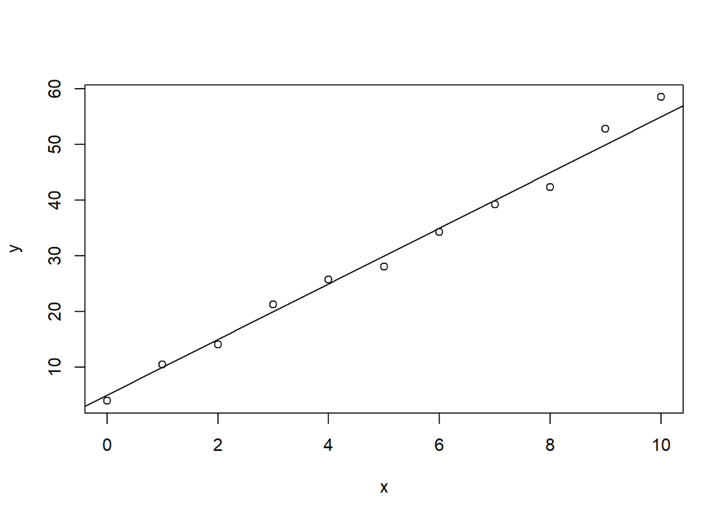

```r
# Create x samples
set.seed(11451)
x = 0:10
n = length(x)
b0 <- 5
b1 <- 5
y = b0 + b1*x + rnorm(n,mean=0,sd=2)
# The real values we created
df <- as.data.frame(cbind(x,y))
plot(df)
abline(b0, b1)
```

We fit this with regression.

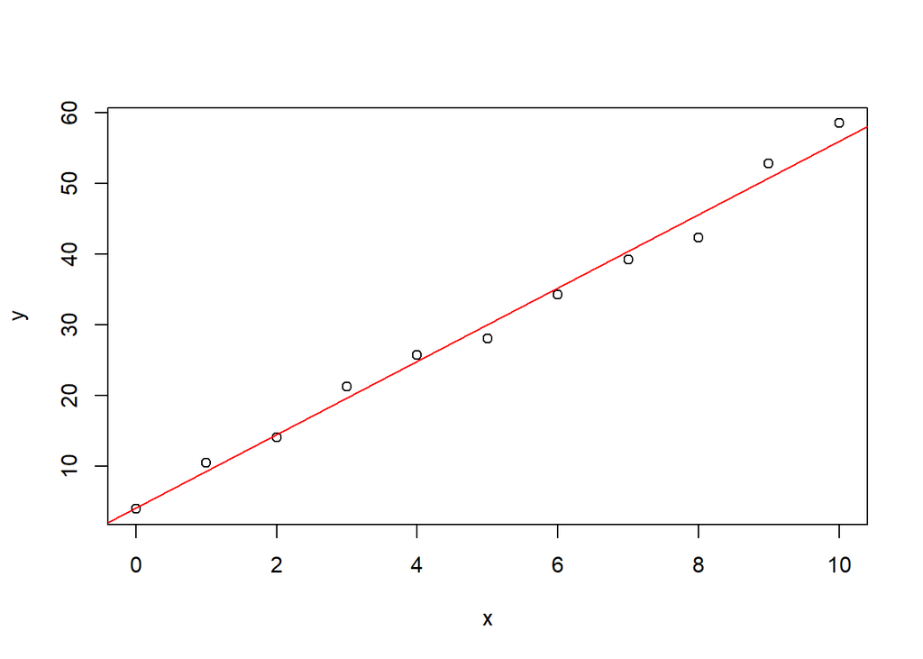

```r
# Model without outliers
model1 <- lm(y~x)
coefs1 <- model1$coefficients
plot(x, y)
abline(coefs1[1], coefs1[2], col = 'red')
```

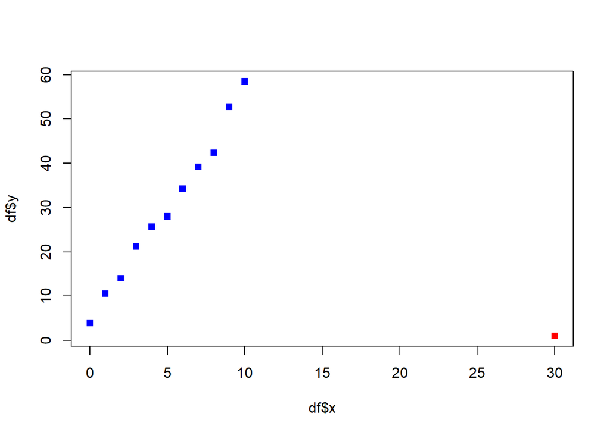

```r
out <- 1
df <- rbind(df, c(30,out))
plot(df$x,df$y, col = ifelse(df$y==out, "red","blue"), pch=15)
```

We try to fit the model again and compute the leverage

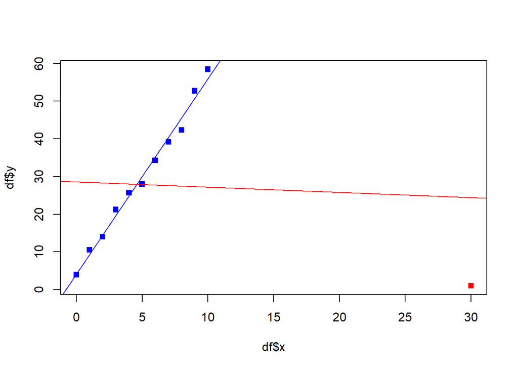

```r
model2 <- lm(df$y~df$x)
coefs2 <- model2$coefficients
plot(df$x,df$y, col = ifelse(df$y==out, "red","blue"), pch=15)
abline(coefs1[1], coefs1[2], col = 'blue')
abline(coefs2[1], coefs2[2], col = 'red')
```

To compute the leverage, we use `hatvalues()` function

```r
hats <- as.data.frame(hatvalues(model2))
tail(hats)
```

|  | hatvalues(model2) |
| --- | --- |
| 7 | 0.08505186 |
| 8 | 0.08334350 |
| 9 | 0.08456376 |
| 10 | 0.08871263 |
| 11 | 0.09579012 |
| 12 | 0.85234899 |

Indeed, the last value has a leverage above $0.5$ and close to $1$. We now try to interpret this.

Note the leverage is the diagonal entry of $P=X(X^TX)^{-1}X^T$ and therefore the influence of the $k^{th}$ value on the fitted $k^{th}$ value is given by

$$\frac{\partial \hat{Y}_k}{\partial Y_k} = P_{kk}$$
A small derivative implies the $k^{th}$ value does not really have a significant impact on the model.

This also implies (in a handwavy way) that the coefficients $\hat{\beta}$ are influenced by $P_{kk}$, as we recall $X\hat{\beta}=\hat{Y}$

Also note the fitted $\hat{y}_k$ is given by
$$\hat{Y}_k = \sum_{j=1}^{n} P_{kj} Y_k$$
And by idempotency of $P$, $P^2=P$

$$P_{kk} = P_{kk}^2 + \sum_{j \neq k} P_{kj}^2$$
which not only shows $P_{kk} \in [0,1]$ but also illustrates that when $P_{kk} \to 1$, $\sum_{j \neq k} P_{kj}^2 \to 0$, therefore $\hat{Y}_k = \sum_{j=1}^{n} P_{kj} Y_k \to P_{kk}Y_k \approx Y_k$.

This again shows the value $Y_k$ has a substantial effect on the model.